# Labo du jeudi — Microsimulation : de la population synthétique aux scénarios de politique

Formation régionale en analyse démographique pour la décision publique — UEMOA, Ouagadougou, 26 novembre 2026

Vissého Adjiwanou (Département de sociologie, UQAM · SSAPOPLAB · Département de démographie, UdeM)

## En bref

- **Durée** : 1 h 30. Le formateur fait la démonstration ; les participants exécutent le code en même temps.
- **Point de départ** : la population synthétique de la commune de Djibo construite mercredi avec Fabrice Yaméogo (83 216 habitants dans 16 159 ménages).
- **Ce qu’on ajoute** : des **taux de transition** — décès, naissances, entrée à l’école — appliqués à **chaque individu**, année après année, de 2025 à 2050.
- **Ce qu’on obtient** : une projection de la population **par niveau d’instruction et par milieu**, et des **scénarios de politique** dont on mesure l’effet **groupe par groupe**.
- **Paquets R** : `tidyverse` seulement. Le paquet `mlfit` n’est utile que pour recréer la population synthétique (script facultatif `00_population_synthetique.R`).

## Objectifs du labo

À la fin du labo, vous serez capables de :

1. expliquer ce qu’une microsimulation ajoute à la projection par composantes : des individus avec leurs caractéristiques, et des taux qui en dépendent ;
2. construire des taux de transition à partir de sources publiées (WPP, EDS, recensement) et de la population elle-même ;
3. simuler une année, puis 25 ans, et contrôler le résultat ;
4. comparer des scénarios de politique et lire leurs effets **par groupe**, pas seulement en moyenne ;
5. dire ce que le modèle ne sait pas faire.

## Déroulé

| Horaire | Étape | Durée |
| --- | --- | --- |
| 0 h 00 | A. Charger la population synthétique de mercredi | 10 min |
| 0 h 10 | B. Les taux de transition | 20 min |
| 0 h 30 | C. Une année simulée, pas à pas | 15 min |
| 0 h 45 | D. Projeter à 2050 et contrôler | 15 min |
| 1 h 00 | E. Tester des scénarios de politique, groupe par groupe | 20 min |
| 1 h 20 | F. Limites et ce qu’il faut retenir | 10 min |

**Un exercice pédagogique.** Djibo est une commune touchée par l’insécurité depuis 2019 : une partie de sa population a été déplacée, et les écoles y sont souvent fermées. Le modèle ignore la migration. Les chiffres servent à apprendre la méthode, pas à planifier pour Djibo.

# A. Charger la population synthétique

```r
library(tidyverse)

# nb() : écrit un nombre à la française (espace pour les milliers, virgule décimale)
nb <- function(x, decimales = 0) {
  format(round(x, decimales), big.mark = " ", decimal.mark = ",",
         nsmall = decimales, trim = TRUE)
}
```

Le fichier `pop_djibo_synthetique.csv` est la population synthétique de mercredi : une ligne par habitant, avec son ménage. Il a été produit par le script `00_population_synthetique.R`, qui reprend exactement les étapes du labo de Fabrice (calage IPU sur les marges du RGPH 2019, poids entiers, réplication des ménages).

```r
pop_brute <- read_csv("donnees/pop_djibo_synthetique.csv", show_col_types = FALSE)

glimpse(pop_brute)
```

```
## Rows: 83,216
## Columns: 8
## $ id          <dbl> 1, 2, 3, 4, 5, 6, 7, 8, 9, 10, 11, 12, 13, 14, 15, 16, 17,…
## $ id_menage   <dbl> 1, 1, 1, 1, 1, 1, 1, 1, 1, 2, 2, 2, 2, 2, 2, 2, 2, 2, 2, 2…
## $ numind      <dbl> 1, 2, 3, 4, 5, 6, 7, 8, 9, 1, 2, 3, 4, 5, 6, 7, 8, 9, 10, …
## $ lien        <chr> "Chef", "Conjoint", "Enfant", "Enfant", "Enfant", "Enfant"…
## $ milieu      <chr> "Urbain", "Urbain", "Urbain", "Urbain", "Urbain", "Urbain"…
## $ sexe        <chr> "Homme", "Femme", "Homme", "Homme", "Femme", "Homme", "Hom…
## $ age         <dbl> 75, 58, 12, 15, 14, 21, 23, 24, 18, 39, 33, 0, 4, 6, 10, 1…
## $ instruction <chr> "Aucun", "Aucun", "Aucun", "Primaire_ou_plus", "Aucun", "P…
```

Pour la microsimulation, chaque individu garde quatre caractéristiques : son sexe, son âge, son milieu (urbain ou rural) et son instruction. On résume l’instruction en une variable logique, `instruit` : la personne a-t-elle fréquenté l’école (niveau primaire ou plus) ?

On ajoute une cinquième caractéristique pour les enfants : **la mère est-elle instruite ?** L’enquête ne relie pas l’enfant à sa mère ; on retient donc une approximation : le chef de ménage ou son conjoint est-il une femme instruite ? C’est le plus souvent la mère des enfants du ménage. Pour les enfants qui naîtront pendant la simulation, on connaîtra la vraie mère.

```r
pop0 <- pop_brute %>%
  mutate(instruit = instruction == "Primaire_ou_plus") %>%
  group_by(id_menage) %>%
  mutate(mere_instruite = any(sexe == "Femme" & lien %in% c("Chef", "Conjoint") & instruit)) %>%
  ungroup() %>%
  mutate(mere_instruite = if_else(age < 15, mere_instruite, NA)) %>%
  select(id, id_menage, milieu, sexe, age, instruit, mere_instruite)

pop0 %>%
  filter(age >= 6) %>%
  group_by(milieu, sexe) %>%
  summarise(habitants_6_ans_plus = n(),
            part_instruits_pct = 100 * mean(instruit), .groups = "drop")
```

| milieu | sexe | habitants_6_ans_plus | part_instruits_pct |
| --- | --- | --- | --- |
| Rural | Femme | 26407 | 4.324611 |
| Rural | Homme | 26158 | 6.583072 |
| Urbain | Femme | 7286 | 60.389789 |
| Urbain | Homme | 6125 | 60.995918 |

**À vous.** Quelle est la part des femmes de 20 à 34 ans qui ont été à l’école, en milieu rural et en milieu urbain ? C’est de ce groupe que viendront la plupart des naissances des dix prochaines années.

# B. Les taux de transition

Une microsimulation tire au sort, chaque année et pour chaque individu, ce qui lui arrive. Il faut donc une probabilité pour chaque événement, qui dépend des caractéristiques de l’individu. Nous en utilisons trois.

| Événement | Qui est concerné | Dépend de | Source |
| --- | --- | --- | --- |
| Décès | tout le monde | âge, sexe, année | Nations Unies, WPP 2024, Burkina Faso, variante moyenne |
| Naissance | femmes de 15 à 49 ans | âge, instruction | EDS 2021 (calendrier rural) et RGPH 2019 (ISF par instruction) |
| Entrée à l’école | enfants de 6 à 9 ans | sexe, milieu, instruction de la mère | estimée dans la population synthétique |

## Mortalité

Les taux de mortalité `mx` du WPP 2024 sont donnés par groupe d’âges, par sexe et par période de cinq ans. Une probabilité annuelle de décéder s’en déduit par $q = 1 - e^{-m}$.

```r
taux_mort <- read_csv("donnees/mortalite_bfa_wpp2024.csv", show_col_types = FALSE) %>%
  mutate(sexe = if_else(sexe == "hommes", "Homme", "Femme"),
         q = 1 - exp(-mx)) %>%
  select(periode, sexe, age_debut, q)

taux_mort %>%
  filter(periode == "2025-2030", age_debut %in% c(0, 1, 30, 60)) %>%
  mutate(q_pour_mille = 1000 * q) %>%
  select(-q)
```

| periode | sexe | age_debut | q_pour_mille |
| --- | --- | --- | --- |
| 2025-2030 | Homme | 0 | 58.772119 |
| 2025-2030 | Homme | 1 | 7.451261 |
| 2025-2030 | Homme | 30 | 4.351007 |
| 2025-2030 | Homme | 60 | 26.568479 |
| 2025-2030 | Femme | 0 | 45.641985 |
| 2025-2030 | Femme | 1 | 6.395382 |
| 2025-2030 | Femme | 30 | 3.368603 |
| 2025-2030 | Femme | 60 | 18.806705 |

## Fécondité

Le recensement de 2019 donne l’ISF selon l’instruction de la femme : 6,0 enfants sans instruction, 5,3 avec le primaire, 4,7 avec le post-primaire. Les femmes instruites de Djibo ont surtout le niveau primaire : on retient **6,0 pour les femmes sans instruction et 5,0 pour les femmes instruites**. Le calendrier, c’est-à-dire la répartition des naissances selon l’âge, vient de l’EDS 2021 en milieu rural.

```r
fec <- read_csv("donnees/fecondite_age_eds2021.csv", show_col_types = FALSE) %>%
  mutate(age_debut = as.integer(substr(groupe_age, 1, 2)),
         calendrier = taux_rural_eds2021 / sum(taux_rural_eds2021) / 5)  # somme de 5 x calendrier = 1

isf_groupe <- c(Aucun = 6.0, Instruite = 5.0)

fec %>%
  mutate(taux_aucun     = calendrier * isf_groupe["Aucun"],
         taux_instruite = calendrier * isf_groupe["Instruite"]) %>%
  select(groupe_age, taux_aucun, taux_instruite)
```

| groupe_age | taux_aucun | taux_instruite |
| --- | --- | --- |
| 15-19 | 0.1349544 | 0.1124620 |
| 20-24 | 0.2699088 | 0.2249240 |
| 25-29 | 0.2735562 | 0.2279635 |
| 30-34 | 0.2322188 | 0.1935157 |
| 35-39 | 0.1750760 | 0.1458967 |
| 40-44 | 0.0851064 | 0.0709220 |
| 45-49 | 0.0291793 | 0.0243161 |

Chaque taux est une probabilité annuelle d’avoir un enfant. Une femme de 25-29 ans sans instruction a environ une chance sur quatre d’accoucher dans l’année.

## Entrée à l’école

Aucun annuaire ne donne la probabilité d’aller à l’école selon le sexe, le milieu **et** l’instruction de la mère. On l’estime dans la population elle-même : parmi les enfants de 10 à 14 ans, quelle part a déjà fréquenté l’école ? Une régression logistique lisse les petits groupes.

```r
modele_scol <- glm(instruit ~ sexe + milieu + mere_instruite,
                   family = binomial,
                   data = pop0 %>% filter(between(age, 10, 14)))

taux_scol <- expand_grid(sexe = c("Femme", "Homme"),
                         milieu = c("Rural", "Urbain"),
                         mere_instruite = c(FALSE, TRUE)) %>%
  mutate(p_scol = predict(modele_scol, newdata = ., type = "response"))

taux_scol %>% mutate(p_scol_pct = 100 * p_scol) %>% select(-p_scol)
```

| sexe | milieu | mere_instruite | p_scol_pct |
| --- | --- | --- | --- |
| Femme | Rural | FALSE | 10.590354 |
| Femme | Rural | TRUE | 46.834229 |
| Femme | Urbain | FALSE | 65.993958 |
| Femme | Urbain | TRUE | 93.520331 |
| Homme | Rural | FALSE | 7.930904 |
| Homme | Rural | TRUE | 39.048172 |
| Homme | Urbain | FALSE | 58.529235 |
| Homme | Urbain | TRUE | 91.301544 |

`p_scol` est la probabilité d’être entré à l’école avant 10 ans. On la transforme en une probabilité annuelle `h`, la même de 6 à 9 ans, telle qu’après quatre années on retrouve `p_scol` : $1 - (1 - h)^4 = p_{scol}$.

**À vous.** Lisez le tableau : quel facteur compte le plus, le milieu ou l’instruction de la mère ? Dans cette population, les filles sont-elles moins scolarisées que les garçons ?

# C. Une année simulée, pas à pas

Une année de simulation enchaîne quatre étapes : les décès, les naissances, les entrées à l’école, puis le vieillissement de tout le monde d’un an. Pour chaque individu, on tire un nombre au hasard entre 0 et 1 (`runif()`) : si ce nombre est inférieur à sa probabilité, l’événement a lieu.

```r
# groupe d'âges du WPP correspondant à un âge (0, 1-4, 5-9, ..., 100+)
groupe_wpp <- function(age) {
  case_when(age == 0 ~ 0L, age < 5 ~ 1L, TRUE ~ as.integer(pmin(age %/% 5 * 5, 100)))
}

# une_annee() : fait passer la population de l'année an à l'année an + 1
#   scenario : liste de paramètres de politique (voir la partie E)
une_annee <- function(pop, an, scenario) {
  periode <- paste0(an - an %% 5, "-", an - an %% 5 + 5)

  # 1. Décès
  pop <- pop %>%
    mutate(age_debut = groupe_wpp(age)) %>%
    left_join(taux_mort %>% filter(periode == !!periode) %>% select(-periode),
              by = c("sexe", "age_debut")) %>%
    mutate(decede = runif(n()) < q)
  deces <- pop %>% filter(decede) %>% count(milieu, name = "deces")
  pop <- pop %>% filter(!decede) %>% select(-age_debut, -q, -decede)

  # 2. Naissances
  meres <- pop %>%
    filter(sexe == "Femme", between(age, 15, 49)) %>%
    mutate(age_debut = age %/% 5 * 5) %>%
    left_join(fec %>% select(age_debut, calendrier), by = "age_debut") %>%
    mutate(isf = if_else(instruit, isf_groupe["Instruite"],
                         isf_groupe["Aucun"] * scenario$mult_fec_aucun),
           naissance = runif(n()) < calendrier * isf)
  bebes <- meres %>%
    filter(naissance) %>%
    transmute(id_menage, milieu,
              sexe = if_else(runif(n()) < 1.05 / 2.05, "Homme", "Femme"),
              age = -1, instruit = FALSE,
              mere_instruite = instruit)          # la vraie mère, cette fois
  bebes$id <- max(pop$id) + seq_len(nrow(bebes))

  # 3. Entrées à l'école (6-9 ans)
  h <- taux_ecole(scenario)
  pop <- pop %>%
    left_join(h, by = c("sexe", "milieu", "mere_instruite")) %>%
    mutate(instruit = instruit | (between(age, 6, 9) & !is.na(h) & runif(n()) < h)) %>%
    select(-h)

  # 4. Vieillissement
  pop <- bind_rows(pop, bebes) %>% mutate(age = age + 1)

  list(pop = pop, meres = meres, deces = deces)
}
```

La fonction `taux_ecole()` applique le scénario de politique aux probabilités d’entrée à l’école. Dans le scénario de référence, elle les laisse inchangées.

```r
taux_ecole <- function(scenario) {
  taux_scol %>%
    # politique « écoles en milieu rural » : les enfants ruraux ont les chances des urbains
    left_join(taux_scol %>% filter(milieu == "Urbain") %>% select(sexe, mere_instruite, p_urbain = p_scol),
              by = c("sexe", "mere_instruite")) %>%
    mutate(p = if (scenario$rural_comme_urbain) p_urbain else p_scol,
           # politique « scolarisation universelle » : un plancher pour tous
           p = pmax(p, scenario$p_min_scol),
           h = 1 - (1 - p)^(1 / 4)) %>%
    select(sexe, milieu, mere_instruite, h)
}

reference <- list(rural_comme_urbain = FALSE, p_min_scol = 0, mult_fec_aucun = 1)
```

Simulons l’année 2025.

```r
set.seed(2026)
essai <- une_annee(pop0, 2025, reference)

tibble(`Population au 1er janvier 2025` = nrow(pop0),
       `Décès` = sum(essai$deces$deces),
       `Naissances` = sum(essai$meres$naissance),
       `Population au 1er janvier 2026` = nrow(essai$pop)) %>%
  pivot_longer(everything(), names_to = "Composante", values_to = "Effectif")
```

| Composante | Effectif |
| --- | --- |
| Population au 1er janvier 2025 | 83216 |
| Décès | 608 |
| Naissances | 3677 |
| Population au 1er janvier 2026 | 86285 |

**À vous.** Calculez le taux brut de natalité et le taux brut de mortalité (pour 1 000 habitants). Sont-ils plausibles pour une commune sahélienne ? Que donne l’équation de bilan ?

# D. Projeter à 2050 et contrôler

La fonction `simuler()` répète `une_annee()` de 2025 à 2049 et note, chaque année, quelques indicateurs pour l’ensemble et pour chaque milieu.

```r
# indicateurs() : résumé d'une année, pour un groupe d'individus
indicateurs <- function(pop, meres) {
  isf <- function(m) {
    m %>% group_by(age_debut) %>% summarise(t = mean(naissance), .groups = "drop") %>%
      summarise(isf = 5 * sum(t)) %>% pull(isf)
  }
  tibble(population            = nrow(pop),
         naissances            = sum(meres$naissance),
         isf                   = isf(meres),
         isf_aucun             = isf(meres %>% filter(!instruit)),
         isf_instruite         = isf(meres %>% filter(instruit)),
         enfants_6_11          = sum(between(pop$age, 6, 11)),
         scolarises_6_11       = sum(pop$instruit[between(pop$age, 6, 11)]),
         scolarises_6_11_pct   = 100 * mean(pop$instruit[between(pop$age, 6, 11)]),
         ecole_10_14_pct       = 100 * mean(pop$instruit[between(pop$age, 10, 14)]),
         femmes_20_34_inst_pct = 100 * mean(pop$instruit[pop$sexe == "Femme" & between(pop$age, 20, 34)]))
}

simuler <- function(scenario, nom, graine = 1, annees = 2025:2049) {
  set.seed(graine)
  pop <- pop0
  suivi <- vector("list", length(annees))
  for (k in seq_along(annees)) {
    res <- une_annee(pop, annees[k], scenario)
    pop <- res$pop
    suivi[[k]] <- bind_rows(
      indicateurs(pop, res$meres) %>% mutate(groupe = "Ensemble"),
      indicateurs(pop %>% filter(milieu == "Rural"),  res$meres %>% filter(milieu == "Rural"))  %>% mutate(groupe = "Rural"),
      indicateurs(pop %>% filter(milieu == "Urbain"), res$meres %>% filter(milieu == "Urbain")) %>% mutate(groupe = "Urbain")
    ) %>% mutate(annee = annees[k] + 1)
  }
  bind_rows(suivi) %>% mutate(scenario = nom, replication = graine)
}
```

Le hasard intervient à chaque tirage : deux simulations ne donnent pas exactement le même résultat. On répète donc chaque scénario plusieurs fois (ici trois, avec trois graines différentes) et l’on regarde la moyenne et l’écart entre les répétitions. Chaque simulation prend quelques secondes.

```r
res_ref <- map_dfr(1:3, ~ simuler(reference, "Référence", graine = .x))

res_ref %>%
  filter(groupe == "Ensemble", annee %in% c(2026, 2030, 2040, 2050)) %>%
  group_by(annee) %>%
  summarise(population = mean(population), naissances = mean(naissances),
            isf = mean(isf), scolarises_6_11_pct = mean(scolarises_6_11_pct),
            ecole_10_14_pct = mean(ecole_10_14_pct),
            femmes_20_34_inst_pct = mean(femmes_20_34_inst_pct))
```

| annee | population | naissances | isf | scolarises_6_11_pct | ecole_10_14_pct | femmes_20_34_inst_pct |
| --- | --- | --- | --- | --- | --- | --- |
| 2026 | 86253.33 | 3643.333 | 5.799326 | 14.59752 | 22.88731 | 22.40138 |
| 2030 | 99800.67 | 4261.667 | 5.854047 | 12.54779 | 22.24835 | 22.79156 |
| 2040 | 141796.33 | 5934.667 | 5.797130 | 12.64047 | 21.58871 | 23.77163 |
| 2050 | 199217.67 | 7826.000 | 5.732305 | 11.26225 | 19.73636 | 22.54141 |

## Contrôler

Un modèle se contrôle avant de servir. Quatre vérifications :

1. **La scolarisation.** Le modèle donne environ 15 % des enfants de 6 à 11 ans scolarisés. L’annuaire de l’enseignement primaire 2023/2024 donne, pour la province du Soum (chef-lieu : Djibo), un taux brut de scolarisation de 17,5 %. L’ordre de grandeur est le bon.
2. **La fécondité.** L’ISF simulé, près de 5,8, est proche de celui des femmes sans instruction (6,0), parce qu’elles sont la grande majorité. L’EDS 2003 et l’EDS 2010 donnaient 7,4 à 7,5 pour la région du Sahel ; la baisse nationale depuis rend une valeur plus basse plausible.
3. **La tendance.** Dans la référence, la part des enfants scolarisés baisse lentement (de 15 % à 11 % en 2050), alors qu’aucun taux ne change. Les familles rurales, moins scolarisées, ont plus d’enfants : leur poids parmi les enfants augmente. C’est un **effet de composition**.
4. **La croissance.** Sans migration, la population passe d’environ 83 000 à près de 200 000 habitants en 2050. C’est la croissance naturelle seule, autour de 3,5 % par an : dans la réalité, les départs et les déplacements la réduisent fortement.

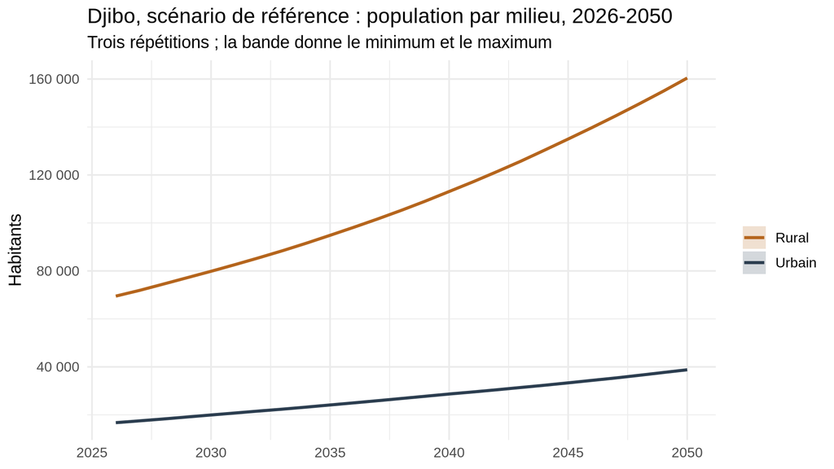

```r
res_ref %>%
  filter(groupe != "Ensemble") %>%
  group_by(annee, groupe) %>%
  summarise(moy = mean(population), bas = min(population), haut = max(population), .groups = "drop") %>%
  ggplot(aes(annee, moy, colour = groupe, fill = groupe)) +
  geom_ribbon(aes(ymin = bas, ymax = haut), alpha = 0.2, colour = NA) +
  geom_line(linewidth = 1) +
  scale_y_continuous(labels = function(x) nb(x)) +
  scale_colour_manual(values = c(Rural = "#b5651d", Urbain = "#2c3e50"), aesthetics = c("colour", "fill")) +
  labs(title = "Djibo, scénario de référence : population par milieu, 2026-2050",
       subtitle = "Trois répétitions ; la bande donne le minimum et le maximum",
       x = NULL, y = "Habitants", colour = NULL, fill = NULL) +
  theme_minimal(base_size = 12)
```

# E. Tester des scénarios de politique, groupe par groupe

On compare quatre politiques au scénario de référence. Chacune agit sur **un groupe précis** : c’est ce qu’une projection agrégée ne permet pas.

| Scénario | Politique | Paramètre modifié |
| --- | --- | --- |
| Écoles rurales | Les enfants ruraux ont les mêmes chances d’aller à l’école que les urbains | `rural_comme_urbain = TRUE` |
| École pour tous | Au moins 80 % des enfants entrent à l’école, quel que soit le groupe | `p_min_scol = 0.8` |
| Planification familiale | La fécondité des femmes sans instruction baisse de 15 % | `mult_fec_aucun = 0.85` |
| École et planification | Les deux dernières politiques ensemble | les deux |

```r
scenarios <- list(
  "Référence"               = reference,
  "Écoles rurales"          = list(rural_comme_urbain = TRUE,  p_min_scol = 0,   mult_fec_aucun = 1),
  "École pour tous"         = list(rural_comme_urbain = FALSE, p_min_scol = 0.8, mult_fec_aucun = 1),
  "Planification familiale" = list(rural_comme_urbain = FALSE, p_min_scol = 0,   mult_fec_aucun = 0.85),
  "École et planification"  = list(rural_comme_urbain = FALSE, p_min_scol = 0.8, mult_fec_aucun = 0.85)
)

resultats <- imap_dfr(scenarios, function(sc, nom) {
  map_dfr(1:3, ~ simuler(sc, nom, graine = .x))     # mêmes graines pour tous les scénarios
}) %>%
  mutate(scenario = factor(scenario, levels = names(scenarios)))
```

## Les trajectoires

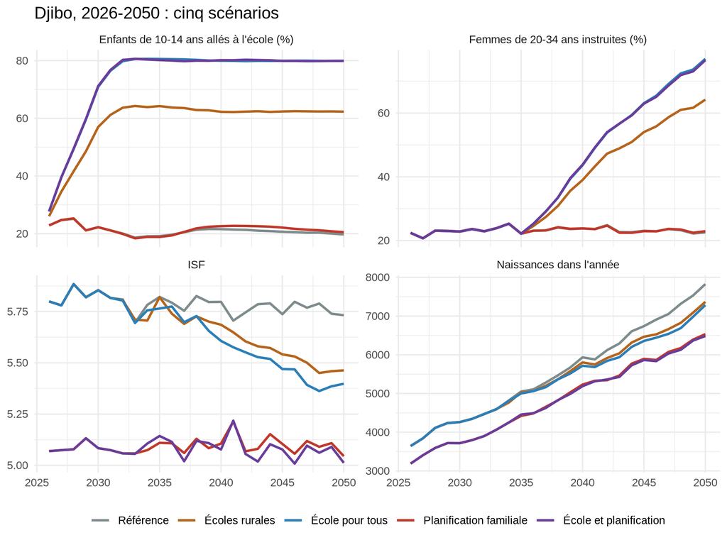

```r
resultats %>%
  filter(groupe == "Ensemble") %>%
  select(scenario, annee, replication, `Naissances dans l'année` = naissances,
         `Enfants de 10-14 ans allés à l'école (%)` = ecole_10_14_pct,
         `Femmes de 20-34 ans instruites (%)` = femmes_20_34_inst_pct, `ISF` = isf) %>%
  pivot_longer(-c(scenario, annee, replication), names_to = "indicateur", values_to = "valeur") %>%
  group_by(scenario, annee, indicateur) %>%
  summarise(valeur = mean(valeur), .groups = "drop") %>%
  ggplot(aes(annee, valeur, colour = scenario)) +
  geom_line(linewidth = 0.9) +
  facet_wrap(~ indicateur, scales = "free_y") +
  scale_colour_manual(values = c("#7f8c8d", "#b5651d", "#2c7fb8", "#c0392b", "#6a3d9a")) +
  labs(title = "Djibo, 2026-2050 : cinq scénarios", x = NULL, y = NULL, colour = NULL) +
  theme_minimal(base_size = 11) +
  theme(legend.position = "bottom")
```

Quand une politique ne touche pas un indicateur, sa courbe se confond avec celle de la référence : la planification familiale ne change pas la scolarisation, et les deux scénarios « école » se superposent pour la scolarisation et l’instruction des femmes.

## Les effets en 2050, groupe par groupe

L’effet d’une politique est l’écart avec le scénario de référence, **à graines égales** : chaque répétition d’un scénario est comparée à la même répétition de la référence.

```r
effets_2050 <- resultats %>%
  filter(annee == 2050) %>%
  select(scenario, replication, groupe, population, naissances, isf,
         ecole_10_14_pct, scolarises_6_11, femmes_20_34_inst_pct) %>%
  pivot_longer(-c(scenario, replication, groupe), names_to = "indicateur", values_to = "valeur") %>%
  group_by(replication, groupe, indicateur) %>%
  mutate(ecart = valeur - valeur[scenario == "Référence"]) %>%
  group_by(scenario, groupe, indicateur) %>%
  summarise(valeur = mean(valeur), ecart = mean(ecart), .groups = "drop")

effets_2050 %>%
  filter(indicateur %in% c("naissances", "ecole_10_14_pct", "isf")) %>%
  mutate(texte = if_else(scenario == "Référence",
                         nb(valeur, if_else(indicateur == "naissances", 0, 1)),
                         paste0(if_else(ecart >= 0, "+", ""), nb(ecart, if_else(indicateur == "naissances", 0, 1))))) %>%
  select(indicateur, groupe, scenario, texte) %>%
  pivot_wider(names_from = scenario, values_from = texte) %>%
  arrange(indicateur, groupe)
```

| indicateur | groupe | Référence | Écoles rurales | École pour tous | Planification familiale | École et planification |
| --- | --- | --- | --- | --- | --- | --- |
| ecole_10_14_pct | Ensemble | 19,7 | +42,6 | +60,2 | +0,8 | +60,2 |
| ecole_10_14_pct | Rural | 9,3 | +53,1 | +70,7 | 0,0 | +70,7 |
| ecole_10_14_pct | Urbain | 62,2 | +0,1 | +17,6 | +0,0 | +17,7 |
| isf | Ensemble | 5,7 | -0,3 | -0,3 | -0,7 | -0,7 |
| isf | Rural | 5,9 | -0,3 | -0,4 | -0,9 | -0,9 |
| isf | Urbain | 5,1 | +0,0 | +0,1 | +0,0 | +0,0 |
| naissances | Ensemble | 7 826,0 | -459,0 | -541,0 | -1 293,0 | -1 341,0 |
| naissances | Rural | 6 452,0 | -459,0 | -564,0 | -1 265,0 | -1 312,0 |
| naissances | Urbain | 1 374,0 | +0,0 | +23,0 | -27,0 | -29,0 |

La colonne « Référence » donne la valeur en 2050 ; les autres colonnes donnent l’écart avec la référence.

**Ce qu’il faut lire dans ce tableau.**

- **Une même politique n’a pas le même effet partout.** « Écoles rurales » ne change rien en ville et transforme la scolarisation à la campagne. Une moyenne pour l’ensemble de la commune cacherait où se trouve l’effet.
- **La planification familiale agit surtout là où vivent les femmes sans instruction**, c’est-à-dire en milieu rural.
- **L’école réduit la fécondité, mais tard.** Les filles scolarisées en 2026 n’ont que 30 ans en 2050. L’ISF de chaque groupe ne change pas, mais la part des femmes instruites augmente : l’ISF d’ensemble baisse par **effet de composition**. Une projection par composantes qui garde un ISF constant ne voit pas ce mécanisme.
- **Il y a un effet de second tour.** Les enfants des femmes devenues instruites ont plus de chances d’aller à l’école à leur tour (la variable `mere_instruite`). Il commence à peine à jouer en 2050.

**À vous.** Quel scénario donne le plus d’enfants scolarisés en 2050 en nombre, et non en pourcentage ? Pourquoi les deux classements peuvent-ils différer ? Pensez aux besoins en enseignants : combien en faudrait-il avec 45 élèves par maître ? Indice : `effets_2050 %>% filter(indicateur == "scolarises_6_11")`.

# F. Limites et ce qu’il faut retenir

## Ce que le modèle ne sait pas faire

- **Pas de migration.** À Djibo, c’est la composante la plus importante depuis 2019.
- **Des taux constants.** La mortalité suit le WPP, mais la fécondité par groupe et les chances d’aller à l’école ne changent qu’avec les politiques testées.
- **Des ménages figés.** Personne ne se marie, ne quitte son ménage ou n’en fonde un nouveau ; les enfants restent dans le ménage de leur mère.
- **Une population construite à partir de 453 ménages de l’EHCVM.** Chaque ménage de l’enquête est recopié en moyenne 35 fois : la diversité de la population synthétique ne dépasse pas celle de l’échantillon.
- **L’instruction de la mère est approchée** pour les enfants déjà nés en 2025 : on prend celle de la femme chef de ménage ou conjointe du chef.
- **Les liens de cause à effet sont supposés, pas démontrés.** Le modèle *suppose* que l’école réduit la fécondité de 6,0 à 5,0 enfants. C’est une différence observée au recensement ; une part peut venir d’autres caractéristiques des femmes instruites (milieu, richesse). Un scénario n’est crédible que si le levier qu’il active a été évalué : c’est le lien avec le cours de ce matin.

## Ce qu’il faut retenir

1. Une microsimulation projette des **individus** et non des effectifs : on peut y suivre tout ce qui caractérise les individus (instruction, milieu, lien avec la mère).
2. Elle a besoin de **taux de transition qui dépendent de ces caractéristiques** ; ils viennent des EDS, des recensements ou de la population elle-même.
3. Le résultat est **aléatoire** : on répète la simulation et l’on montre l’écart entre répétitions.
4. Son atout pour la décision : **tester une politique sur un groupe précis** et voir son effet **groupe par groupe**, y compris les effets de composition et de second tour.

# Exercice (en équipe pays ou ce soir)

1. **Changez une hypothèse.** Remplacez l’ISF des femmes instruites par 4,7 (le niveau post-primaire du recensement). Comment change l’effet du scénario « École pour tous » sur les naissances en 2050 ?
2. **Inventez une politique.** Ajoutez un paramètre à `scenario` (par exemple : seules les filles bénéficient du plancher de 80 %) et modifiez `taux_ecole()` en conséquence. Comparez son effet à celui de « École pour tous » pour un coût que vous supposerez deux fois plus faible.
3. **Écrivez pour un décideur.** En trois phrases, dites quelle politique vous recommanderiez pour la commune, quel groupe elle touche, et quelle preuve il faudrait pour croire que le levier fonctionne.

**Sources des taux.** Mortalité : Nations Unies, *World Population Prospects 2024*, Burkina Faso, variante moyenne. Calendrier de la fécondité : EDS Burkina Faso 2021, rapport des indicateurs clés, tableau 3 (milieu rural). ISF selon l’instruction : INSD, *Baisse de la fécondité au Burkina Faso*, d’après le RGPH 2019, tableau 1. Scolarisation de contrôle : INSD, *La région du Sahel en chiffres*, d’après l’annuaire de l’enseignement primaire 2023/2024. Population synthétique : labo du mercredi (Fabrice Yaméogo), à partir de l’EHCVM et du RGPH 2019.